# TIPOLOGIA Y CICLO DE VIDA DE LOS DATOS

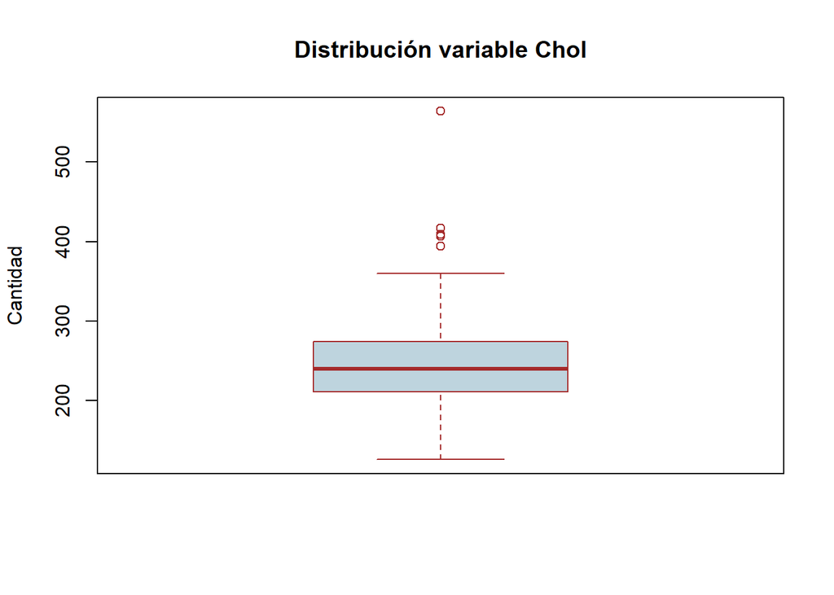

```r
# Variable chol. Podemos ver que existen valores extremos.
boxplot(diseases$chol, main = "Distribución variable Chol", ylab = "Cantidad", col ="#bed4de", border = "brown")
```

```r
# Imprimimos aquellos valores atípicos
boxplot.stats(diseases$chol)$out #Muestra los valores extremos si hubiesen
```

```
## [1] 417 564 394 407 409
```

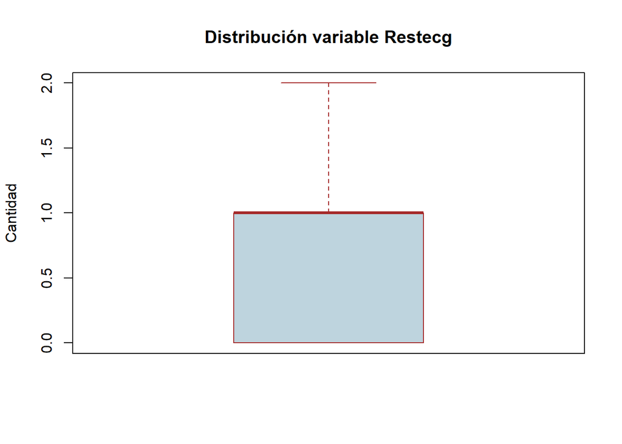

```r
# Variable restecg, no se visualiza valores extremos
boxplot(diseases$restecg, main = "Distribución variable Restecg", ylab = "Cantidad", col ="#bed4de", border = "brown")
```

```r
boxplot.stats(diseases$restecg)$out #Muestra los valores extremos si hubiesen
```

```
## integer(0)
```

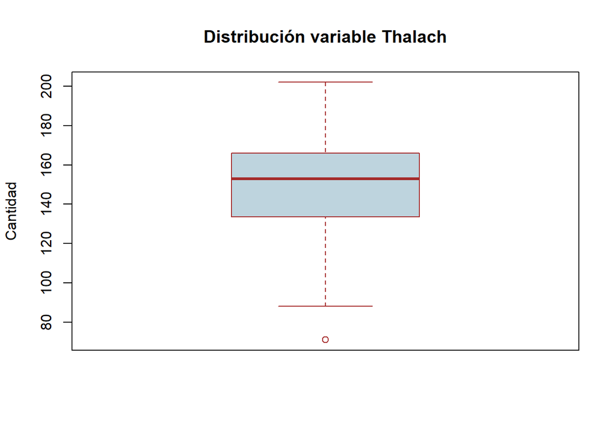

```r
# Variable thalach. Podemos ver que existen valores extremos.
boxplot(diseases$thalach, main = "Distribución variable Thalach", ylab = "Cantidad", col ="#bed4de", border = "brown")
```

```r
# Imprimimos aquellos valores atípicos
boxplot.stats(diseases$thalach)$out #Muestra los valores extremos si hubiesen
```

```
## [1] 71
```

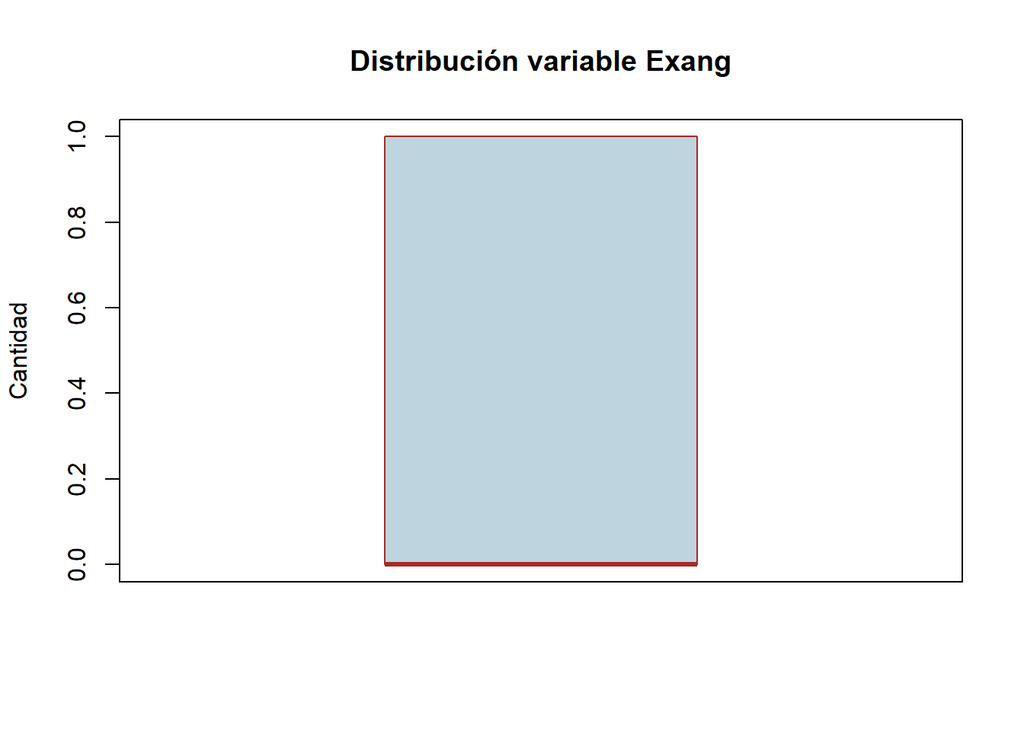

```r
# Variable exang, no se visualiza valores extremos
boxplot(diseases$exang, main = "Distribución variable Exang", ylab = "Cantidad", col ="#bed4de", border = "brown")
```

```r
boxplot.stats(diseases$exang)$out #Muestra los valores extremos si hubiesen
```

```
## integer(0)
```

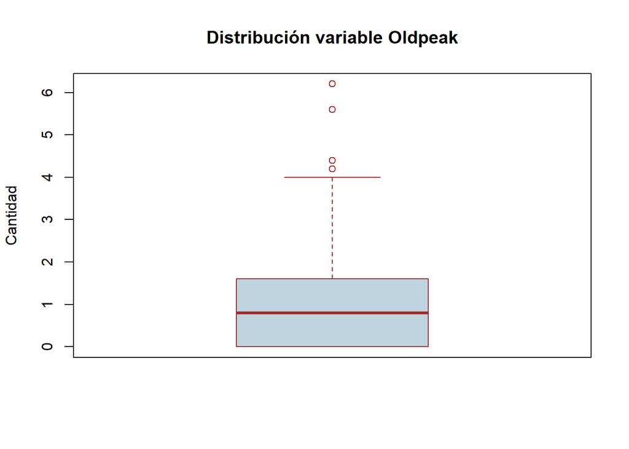

```r
# Variable oldpeak. Podemos ver que existen valores extremos.
boxplot(diseases$oldpeak, main = "Distribución variable Oldpeak", ylab = "Cantidad", col ="#bed4de", border = "brown")
```

```r
# Imprimimos aquellos valores atípicos
boxplot.stats(diseases$oldpeak)$out #Muestra los valores extremos si hubiesen
```

```
## [1] 4.2 6.2 5.6 4.2 4.4
```

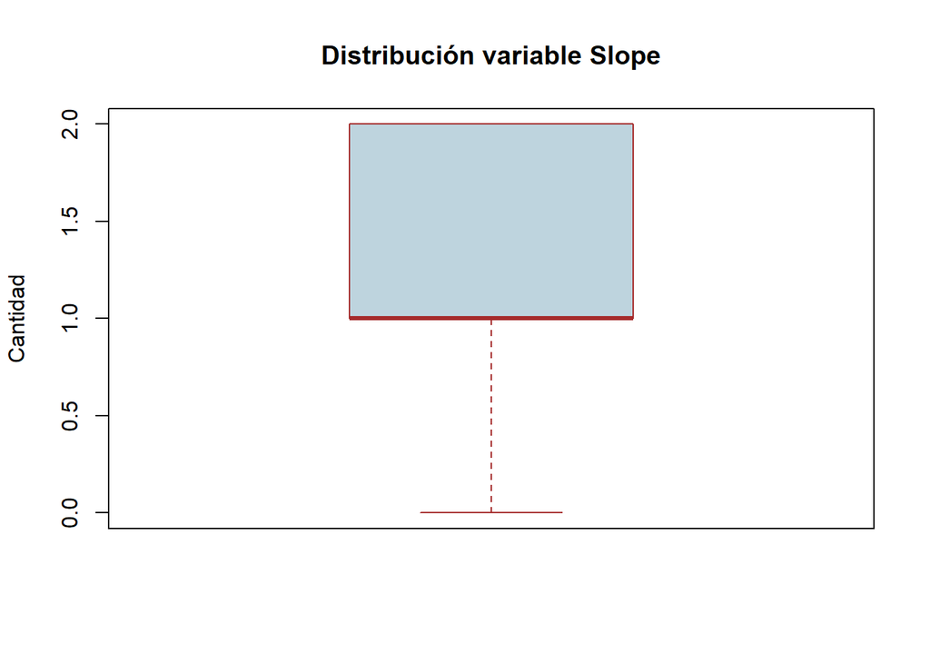

```r
# Variable slope, no se visualiza valores extremos
boxplot(diseases$slope, main = "Distribución variable Slope", ylab = "Cantidad", col ="#bed4de", border = "brown")
```

```r
boxplot.stats(diseases$slope)$out #Muestra los valores extremos si hubiesen
```

```
## integer(0)
```

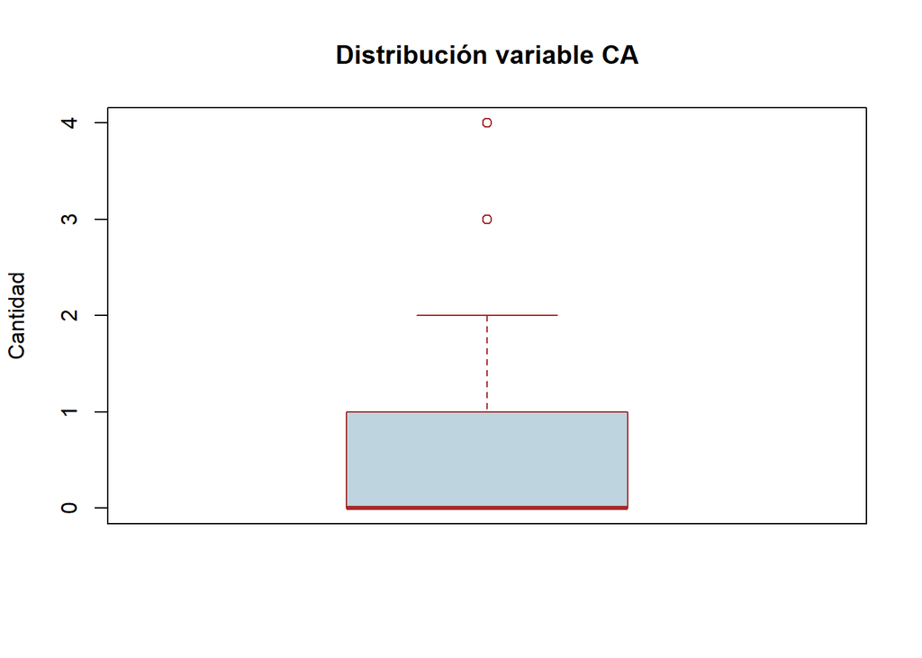

```r
# Variable ca. Podemos ver que existen valores extremos.
boxplot(diseases$ca, main = "Distribución variable CA", ylab = "Cantidad", col ="#bed4de", border = "brown")
```

```r
# Imprimimos aquellos valores atípicos
boxplot.stats(diseases$ca)$out #Muestra los valores extremos si hubiesen
```

```
##  [1] 3 4 3 3 4 4 4 3 3 3 3 3 3 3 3 3 3 3 3 3 4 3 3 3 3
```

Las variables con valores extremos son trestbps, chol, thalach, oldpeak, ca. Estos serán analizados a continuación para ver que realizar con ellos.

- trestbps: Esta variable indica la presión arterial en reposo. Los valores extremos que arroja va desde 172 a 200, con un total de 9 registros. Se revisó la distribución que se describe en el punto 2 y no representan anomalías, ya que se pueden dar estos casos.
- chol: Esta variable indica niveles de colesterol. Los valores que arroja va desde 394 a 564, con un total de 5 registros. Estos valores se escapan considerablemente con el resto de los demás datos. Se eliminarán.
- thalach: Esta variable indica máximos niveles de ritmo cardiaco alcanzado. El valor extremo arrojado es 71, en donde aparece solo una vez en el data set. Este valor es por bajo lo normal, pero dentro de lo esperado para validar si un paciente presenta problemas cardiacos, por lo que no se eliminará.
- oldpeak: Representa la depresión del degmento ST. Los valores que arroja va desde 4.2 a 6.2, con un total de 5 registros. Al revisar estos valores en la distribución de los datos que fueron representados en el punto 2, se escapan del resto de los demás datos, además estos datos extremos se encuentran sesgados en la representación de aquellos pacientes sin problemas cardiacos. Se eliminarán del data set.
- ca: Representa el número de vasos principales coloreados por fluoroscopia. Estos valores extremos que encontramos no representa alteraciones en la realidad o valores que nos vaya a distorcionar nuestros modelos predictivos, por lo que no se eliminarán.

```r
#Eliminamos los valores extremos.
diseases = diseases[diseases$oldpeak < min(boxplot.stats(diseases$oldpeak)$out),]
diseases = diseases[diseases$chol < min(boxplot.stats(diseases$chol)$out),]
```

Finalmente quedamos con 293 registros de 303 iniciales.

### 1.3.3 Correlación entre variables

Revisaremos la correlación entre todas las variables númericas, en donde buscaremos correlaciones menores a -0.5 o mayores a 0.5, siendo 1 y -1 correlaciones perfectas y 0 ninguna correlación, de esta manera consideraremos si es suficiente para una posible eliminación de la variable, por considerarla redundante entre ellas.

```r
cor(diseases$age, diseases$sex) # correlación entre age y sex
```

```
## [1] -0.07600017
```

```r
cor(diseases$age, diseases$cp) # correlación entre age y cp
```

```
## [1] -0.07350791
```

```r
cor(diseases$age, diseases$trestbps) # correlación entre age y trestbps
```

```
## [1] 0.2788777
```

```r
cor(diseases$age, diseases$chol) # correlación entre age y chol
```

```
## [1] 0.1840307
```

```r
cor(diseases$age, diseases$fbs) # correlación entre age y fbs
```

```
## [1] 0.1215168
```

```r
cor(diseases$age, diseases$restecg) # correlación entre age y restecg
```

```
## [1] -0.1032196
```

```r
cor(diseases$age, diseases$thalach) # correlación entre age y thalach
```

```
## [1] -0.4105411
```

```r
cor(diseases$age, diseases$exang) # correlación entre age y exang
```

```
## [1] 0.1144832
```

```r
cor(diseases$age, diseases$oldpeak) # correlación entre age y oldpeak
```

```
## [1] 0.2062777
```

```r
cor(diseases$age, diseases$slope) # correlación entre age y slope
```

```
## [1] -0.1598506
```

```r
cor(diseases$age, diseases$ca) # correlación entre age y ca
```

```
## [1] 0.2813552
```

```r
cor(diseases$sex, diseases$cp) # correlación entre sex y cp
```

```
## [1] -0.05873129
```

```r
cor(diseases$sex, diseases$trestbps) # correlación entre sex y trestbps
```

```
## [1] -0.0510139
```

```r
cor(diseases$sex, diseases$chol) # correlación entre sex y chol
```

```
## [1] -0.1440484
```

```r
cor(diseases$sex, diseases$fbs) # correlación entre sex y fbs
```

```
## [1] 0.05209214
```

```r
cor(diseases$sex, diseases$restecg) # correlación entre sex y restecg
```

```
## [1] -0.1009395
```

```r
cor(diseases$sex, diseases$thalach) # correlación entre sex y thalach
```

```
## [1] -0.03200088
```

```r
cor(diseases$sex, diseases$exang) # correlación entre sex y exang
```

```
## [1] 0.1337944
```

```r
cor(diseases$sex, diseases$oldpeak) # correlación entre sex y oldpeak
```

```
## [1] 0.1272768
```

```r
cor(diseases$sex, diseases$slope) # correlación entre sex y slope
```

```
## [1] -0.03589005
```

```r
cor(diseases$sex, diseases$ca) # correlación entre sex y ca
```

```
## [1] 0.1430607
```

```r
cor(diseases$cp, diseases$trestbps) # correlación entre cp y trestbps
```

```
## [1] 0.04396564
```

```r
cor(diseases$cp, diseases$chol) # correlación entre cp y chol
```

```
## [1] -0.09790354
```

```r
cor(diseases$cp, diseases$fbs) # correlación entre cp y fbs
```

```
## [1] 0.08422713
```

```r
cor(diseases$cp, diseases$restecg) # correlación entre cp y restecg
```

```
## [1] 0.0622962
```

```r
cor(diseases$cp, diseases$thalach) # correlación entre cp y thalach
```

```
## [1] 0.2934913
```

```r
cor(diseases$cp, diseases$exang) # correlación entre cp y exang
```

```
## [1] -0.3945565
```

```r
cor(diseases$cp, diseases$oldpeak) # correlación entre cp y oldpeak
```

```
## [1] -0.1310823
```

```r
cor(diseases$cp, diseases$slope) # correlación entre cp y slope
```

```
## [1] 0.110581
```

```r
cor(diseases$cp, diseases$ca) # correlación entre cp y ca
```

```
## [1] -0.1569964
```

```r
cor(diseases$trestbps, diseases$chol) # correlación entre trestbps y chol
```

```
## [1] 0.1536378
```

```r
cor(diseases$trestbps, diseases$fbs) # correlación entre trestbps y fbs
```

```
## [1] 0.1871295
```

```r
cor(diseases$trestbps, diseases$restecg) # correlación entre trestbps y restecg
```

```
## [1] -0.09404663
```

```r
cor(diseases$trestbps, diseases$thalach) # correlación entre trestbps y thalach
```

```
## [1] -0.04207942
```

```r
cor(diseases$trestbps, diseases$exang) # correlación entre trestbps y exang
```

```
## [1] 0.07529997
```

```r
cor(diseases$trestbps, diseases$oldpeak) # correlación entre trestbps y oldpeak
```

```
## [1] 0.1576912
```

```r
cor(diseases$trestbps, diseases$slope) # correlación entre trestbps y slope
```

```
## [1] -0.09781491
```

```r
cor(diseases$trestbps, diseases$ca) # correlación entre trestbps y ca
```

```
## [1] 0.0964481
```

```r
cor(diseases$chol, diseases$fbs) # correlación entre chol y fbs
```

```
## [1] 0.01127574
```

```r
cor(diseases$chol, diseases$restecg) # correlación entre chol y restecg
```

```
## [1] -0.1290889
```

```r
cor(diseases$chol, diseases$thalach) # correlación entre chol y thalach
```

```
## [1] -0.02989011
```

```r
cor(diseases$chol, diseases$exang) # correlación entre chol y exang
```

```
## [1] 0.1029059
```

```r
cor(diseases$chol, diseases$oldpeak) # correlación entre chol y oldpeak
```

```
## [1] 0.01478626
```

```r
cor(diseases$chol, diseases$slope) # correlación entre chol y slope
```

```
## [1] 0.02482699
```

```r
cor(diseases$chol, diseases$ca) # correlación entre chol y ca
```

```
## [1] 0.05553339
```

```r
cor(diseases$fbs, diseases$restecg) # correlación entre fbs y restecg
```

```
## [1] -0.08147533
```

```r
cor(diseases$fbs, diseases$thalach) # correlación entre fbs y thalach
```

```
## [1] -0.01524296
```

```r
cor(diseases$fbs, diseases$exang) # correlación entre fbs y exang
```

```
## [1] 0.03223467
```

```r
cor(diseases$fbs, diseases$oldpeak) # correlación entre fbs y oldpeak
```

```
## [1] 0.04151467
```

```r
cor(diseases$fbs, diseases$slope) # correlación entre fbs y slope
```

```
## [1] -0.0894874
```

```r
cor(diseases$fbs, diseases$ca) # correlación entre fbs y ca
```

```
## [1] 0.1539619
```

```r
cor(diseases$restecg, diseases$thalach) # correlación entre restecg y thalach
```

```
## [1] 0.06174863
```

```r
cor(diseases$restecg, diseases$exang) # correlación entre restecg y exang
```

```
## [1] -0.08563258
```

```r
cor(diseases$restecg, diseases$oldpeak) # correlación entre restecg y oldpeak
```

```
## [1] -0.08006405
```

```r
cor(diseases$restecg, diseases$slope) # correlación entre restecg y slope
```

```
## [1] 0.1093412
```

```r
cor(diseases$restecg, diseases$ca) # correlación entre restecg y ca
```

```
## [1] -0.09022665
```

```r
cor(diseases$thalach, diseases$exang) # correlación entre thalach y exang
```

```
## [1] -0.3731303
```

```r
cor(diseases$thalach, diseases$oldpeak) # correlación entre thalach y oldpeak
```

```
## [1] -0.3479164
```

```r
cor(diseases$thalach, diseases$slope) # correlación entre thalach y slope
```

```
## [1] 0.3848138
```

```r
cor(diseases$thalach, diseases$ca) # correlación entre thalach y ca
```

```
## [1] -0.2141315
```

```r
cor(diseases$exang, diseases$oldpeak) # correlación entre exang y oldpeak
```

```
## [1] 0.3264294
```

```r
cor(diseases$exang, diseases$slope) # correlación entre exang y slope
```

```
## [1] -0.2741821
```

```r
cor(diseases$exang, diseases$ca) # correlación entre exang y ca
```

```
## [1] 0.1203961
```

```r
cor(diseases$oldpeak, diseases$slope)  # correlación entre oldpeak y slope
```

```
## [1] -0.537684
```

```r
cor(diseases$oldpeak, diseases$ca)  # correlación entre oldpeak y ca
```

```
## [1] 0.1683248
```

```r
cor(diseases$slope, diseases$ca) # correlación entre slope y ca
```

```
## [1] -0.05237711
```

Como podemos observar, existe una correlación negativa moderada -0.537684, entre las variables oldpeak y slope, ésta no es muy alta pero se realizarán las pruebas cuando generemos los modelos predictivos, considerando las dos y luego solo una de ellas para ver si mejora el porcentaje de predicción.

```r
if(!require(PerformanceAnalytics)){
  install.packages('PerformanceAnalytics', repos='http://cran.us.r-project.org')
  library(PerformanceAnalytics)
}
```

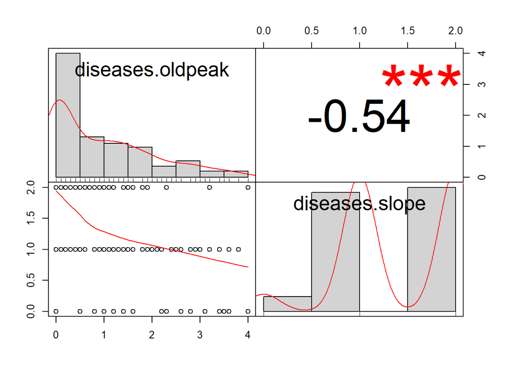

```r
dat1 <- data.frame(diseases$oldpeak, diseases$slope)
chart.Correlation(dat1) # graficamos la correlación
```

Realizado este estudio, vamos a realizar análisis ANOVA para ver si se encuentran diferencias significativas entre las media del valor de trestbps (presión arterial en reposo) y otras variables entre los diferentes grupos de edad. Este estudio nos puede permitir permitir ver las caracteríscas de las variables y quizá sacar alguna conclusión de prioridad de variables a incluir en algun model que queramos estudiar.

```r
anova=aov(diseases$trestbps ~ diseases$age.tipo)
summary (anova)
```

```
##                    Df Sum Sq Mean Sq F value   Pr(>F)
## diseases$age.tipo   4   6781  1695.1    5.96 0.000128 ***
## Residuals         288  81913   284.4
## ---
## Signif. codes:  0 '***' 0.001 '**' 0.01 '*' 0.05 '.' 0.1 ' ' 1
```

Vemos que al ser p-value es inferior a 0.05 sí que hay evidencias suficientes para considerar que al menos dos medias son distintas. No obstante vamos a probar si se cumplen las condiciones para aplicar ANOVA. Revisamos los siguientes gráficos.

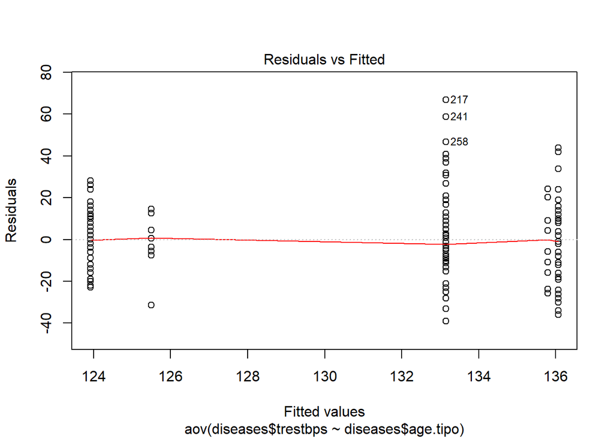

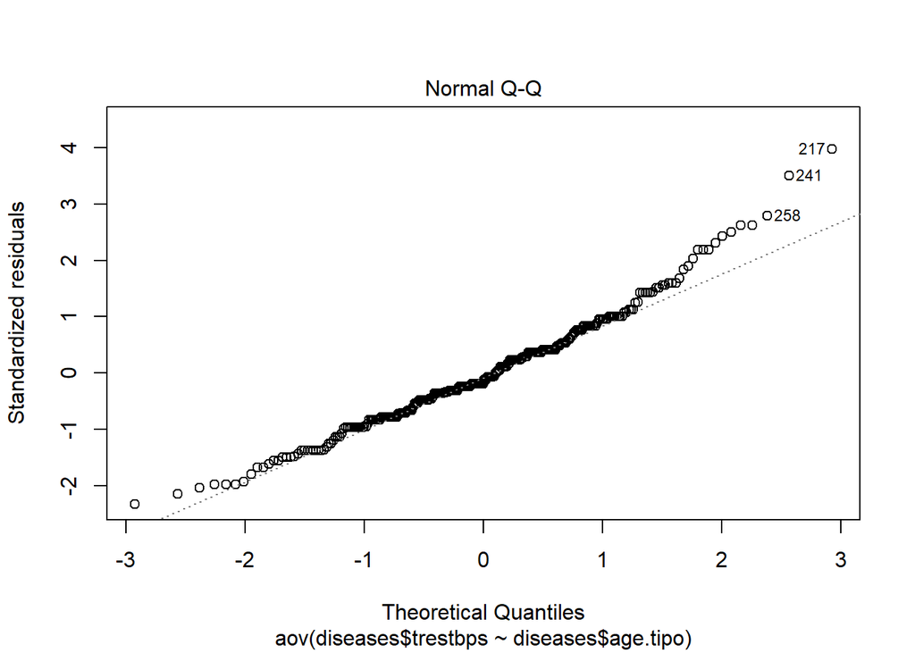

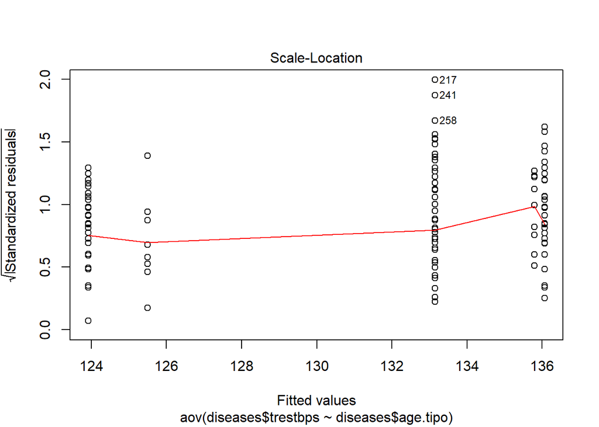

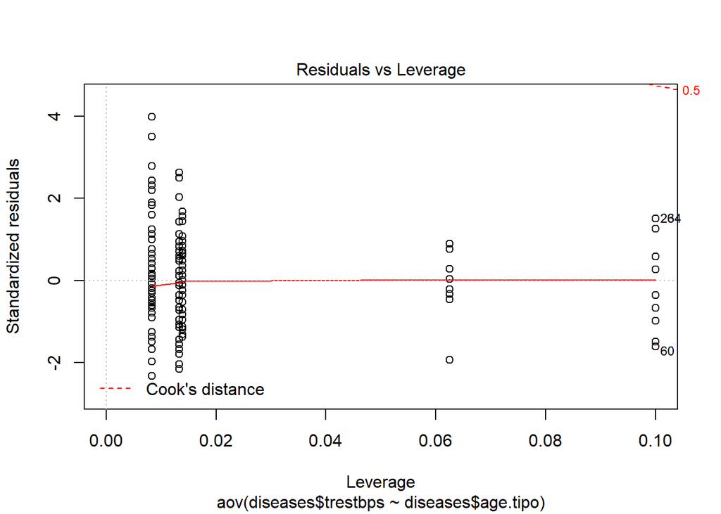

```r
plot( anova)
```

En el gráfico 1, la representación gráfica de los residuos nos muestra falta de homocedasticidad y en el gráfico 2 qqplot vemos que los residuos no se distribuyen cercanos a la linea de la normal. Decidimos aplicar un estudio no paramétrico.

```r
diseases$age.tipo <- as.factor(diseases$age.tipo)
kruskal.test(trestbps ~ age.tipo, data = diseases)
```

```
##
##  Kruskal-Wallis rank sum test
##
## data:  trestbps by age.tipo
## Kruskal-Wallis chi-squared = 21.946, df = 4, p-value = 0.0002055
```

```r
pairwise.wilcox.test(x = diseases$trestbps, g = diseases$age.tipo, p.adjust.method = "holm" )
```

```
##
##  Pairwise comparisons using Wilcoxon rank sum test
##
## data:  diseases$trestbps and diseases$age.tipo
##
##                         Mayor a 40 y menor a 50 Mayor a 50 y menor a 60
## Mayor a 50 y menor a 60 0.0081                  -
## Mayor a 60 y menor a 70 0.0002                  0.8864
## Mayores a 70            0.4207                  1.0000
## Menores a 40            1.0000                  0.7026
##                         Mayor a 60 y menor a 70 Mayores a 70
## Mayor a 50 y menor a 60 -                       -
## Mayor a 60 y menor a 70 -                       -
## Mayores a 70            1.0000                  -
## Menores a 40            0.1289                  0.8864
##
## P value adjustment method: holm
```

También este estudio (test de Kruskal) nos dice que existe diferencias significativas, pero no entre todos los gupos de edad como nos indica el segundo test pairwise.wilcox.

Repetimos este estudio para otras variables:

```r
kruskal.test(thalach ~ age.tipo, data = diseases)
```

```
##
##  Kruskal-Wallis rank sum test
##
## data:  thalach by age.tipo
## Kruskal-Wallis chi-squared = 48.683, df = 4, p-value = 6.8e-10
```

```r
pairwise.wilcox.test(x = diseases$thalach, g = diseases$age.tipo, p.adjust.method = "holm" )
```

```
##
##  Pairwise comparisons using Wilcoxon rank sum test
##
## data:  diseases$thalach and diseases$age.tipo
##
##                         Mayor a 40 y menor a 50 Mayor a 50 y menor a 60
## Mayor a 50 y menor a 60 0.00521                 -
## Mayor a 60 y menor a 70 4.0e-06                 0.02677
## Mayores a 70            0.00196                 0.03960
## Menores a 40            0.03960                 0.00073
##                         Mayor a 60 y menor a 70 Mayores a 70
## Mayor a 50 y menor a 60 -                       -
## Mayor a 60 y menor a 70 -                       -
## Mayores a 70            0.10300                 -
## Menores a 40            3.2e-05                 0.00189
##
## P value adjustment method: holm
```

```r
kruskal.test(oldpeak ~ age.tipo, data = diseases)
```

```
##
##  Kruskal-Wallis rank sum test
##
## data:  oldpeak by age.tipo
## Kruskal-Wallis chi-squared = 23.463, df = 4, p-value = 0.0001023
```

```r
pairwise.wilcox.test(x = diseases$oldpeak, g = diseases$age.tipo, p.adjust.method = "holm" )
```

```
##
##  Pairwise comparisons using Wilcoxon rank sum test
##
## data:  diseases$oldpeak and diseases$age.tipo
##
##                         Mayor a 40 y menor a 50 Mayor a 50 y menor a 60
## Mayor a 50 y menor a 60 0.056                   -
## Mayor a 60 y menor a 70 8.2e-05                 0.068
## Mayores a 70            0.787                   1.000
## Menores a 40            1.000                   0.787
##                         Mayor a 60 y menor a 70 Mayores a 70
## Mayor a 50 y menor a 60 -                       -
## Mayor a 60 y menor a 70 -                       -
## Mayores a 70            1.000                   -
## Menores a 40            0.083                   0.947
##
## P value adjustment method: holm
```

En el caso de thalach (maximo ritmo cardiaco alcanzado) vemos que practicamente entre todos los grupos de edad las medias son significativamente distintas. El resultado para oldpeak (depresión del ST inducida por el ejercicio en relación con el descanso) es más parecido a la variable trestbps (hay diferencia entre los diferentes grupos pero no entre todos entre ellos).

Las conclusiones eran previsibles, los diferentes grupos de edad tienen medias de trestbps, thalch y oldpeak significativamente distintas (entre algunos grupos entre ellos). Sobre todo en thalch vemos medias diferentes practicamente entre todos los grupos. De momento no profundizamos más en este estudio y lo retomaremos si por los modelos que realicemos nos interesa profundizar en el análisis.

# 2 Análisis y pruebas estadísticas

## 2.1 Análisis de los datos.

### 2.1.1 Selección de los grupos de datos que se quieren analizar/comparar (planificación de los análisis a aplicar).

La selección de datos finalmente quedará en los siguiente:

```r
str(diseases)
```

```
## 'data.frame':    293 obs. of  26 variables:
##  $ age          : num  63 37 41 56 57 57 56 44 52 57 ...
##  $ sex          : int  1 1 0 1 0 1 0 1 1 1 ...
##  $ cp           : int  3 2 1 1 0 0 1 1 2 2 ...
##  $ trestbps     : int  145 130 130 120 120 140 140 120 172 150 ...
##  $ chol         : int  233 250 204 236 354 192 294 263 199 168 ...
##  $ fbs          : int  1 0 0 0 0 0 0 0 1 0 ...
##  $ restecg      : int  0 1 0 1 1 1 0 1 1 1 ...
##  $ thalach      : int  150 187 172 178 163 148 153 173 162 174 ...
##  $ exang        : int  0 0 0 0 1 0 0 0 0 0 ...
##  $ oldpeak      : num  2.3 3.5 1.4 0.8 0.6 0.4 1.3 0 0.5 1.6 ...
##  $ slope        : int  0 0 2 2 2 1 1 2 2 2 ...
##  $ ca           : int  0 0 0 0 0 0 0 0 0 0 ...
##  $ target       : int  1 1 1 1 1 1 1 1 1 1 ...
##  $ target.tipo  : chr  "Con Problemas Cardiacos" "Con Problemas Cardiacos" "Con Problemas Cardiacos" "Con Problemas Cardiacos" ...
##  $ age.tipo     : Factor w/ 5 levels "Mayor a 40 y menor a 50",..: 3 5 1 2 2 2 2 1 2 2 ...
##  $ sex.tipo     : chr  "Masculino" "Masculino" "Femenino" "Masculino" ...
##  $ cp.tipo      : Factor w/ 4 levels "0","1","2","3": 4 3 2 2 1 1 2 2 3 3 ...
##  $ trestbps.tipo: chr  "Mayor a 140 y menor a 180" "Mayor a 100 y menor a 150" "Mayor a 100 y menor a 150" "Mayor a 100 y menor a 150" ...
##  $ chol.tipo    : chr  "Mayor a 200 y menor a 300" "Mayor a 200 y menor a 300" "Mayor a 200 y menor a 300" "Mayor a 200 y menor a 300" ...
##  $ fbs.tipo     : Factor w/ 2 levels "0","1": 2 1 1 1 1 1 1 1 2 1 ...
##  $ restecg.tipo : Factor w/ 3 levels "0","1","2": 1 2 1 2 2 2 1 2 2 2 ...
##  $ thalach.tipo : chr  "Mayor a 150 y menor a 200" "Mayor a 150 y menor a 200" "Mayor a 150 y menor a 200" "Mayor a 150 y menor a 200" ...
##  $ exang.tipo   : Factor w/ 2 levels "0","1": 1 1 1 1 2 1 1 1 1 1 ...
##  $ oldpeak.tipo : chr  "Mayor a 2 y menor a 3" "Mayor a 3 y menor a 4" "Mayor a 1 y menor a 2" "Menor a 1" ...
##  $ slope.tipo   : Factor w/ 3 levels "0","1","2": 1 1 3 3 3 2 2 3 3 3 ...
##  $ ca.tipo      : Factor w/ 5 levels "0","1","2","3",..: 1 1 1 1 1 1 1 1 1 1 ...
```

### 2.1.2 Comprobación de la normalidad y homogeneidad de la varianza.

Vamos a probar la normalidad de los datos mediante el test Shapiro–Wilk. Seleccionamos las variables a las que aplica comprobar la normalidad, que son las variables cuantitativas. Visualizamos unos gráficos en columna, que nos ayudará a intuir su distribución.

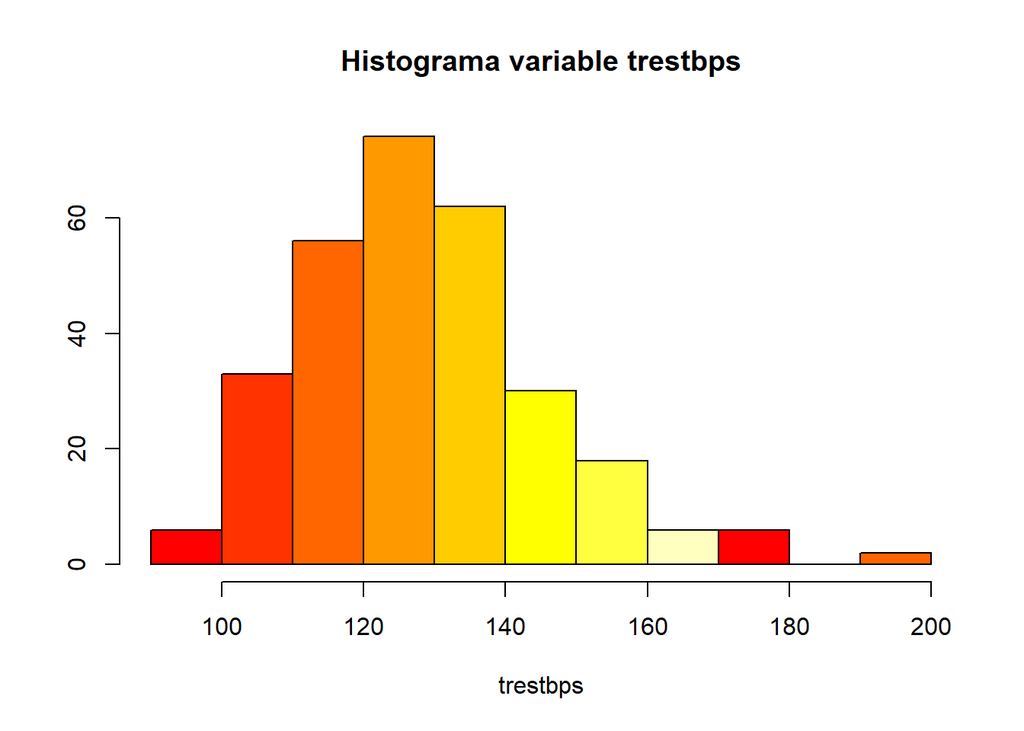

```r
trestbps<-diseases$trestbps
chol<-diseases$chol
thalach<-diseases$thalach
oldpeak<-diseases$oldpeak
hist(trestbps,main = "Histograma variable trestbps",ylab=names("trestbps"),col=heat.colors(8))
```

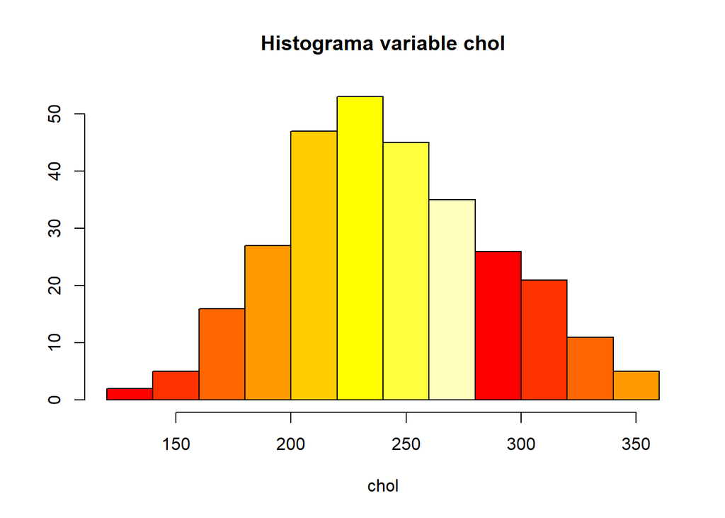

```r
hist(chol,main = "Histograma variable chol",ylab=names("chol"),col=heat.colors(8))
```

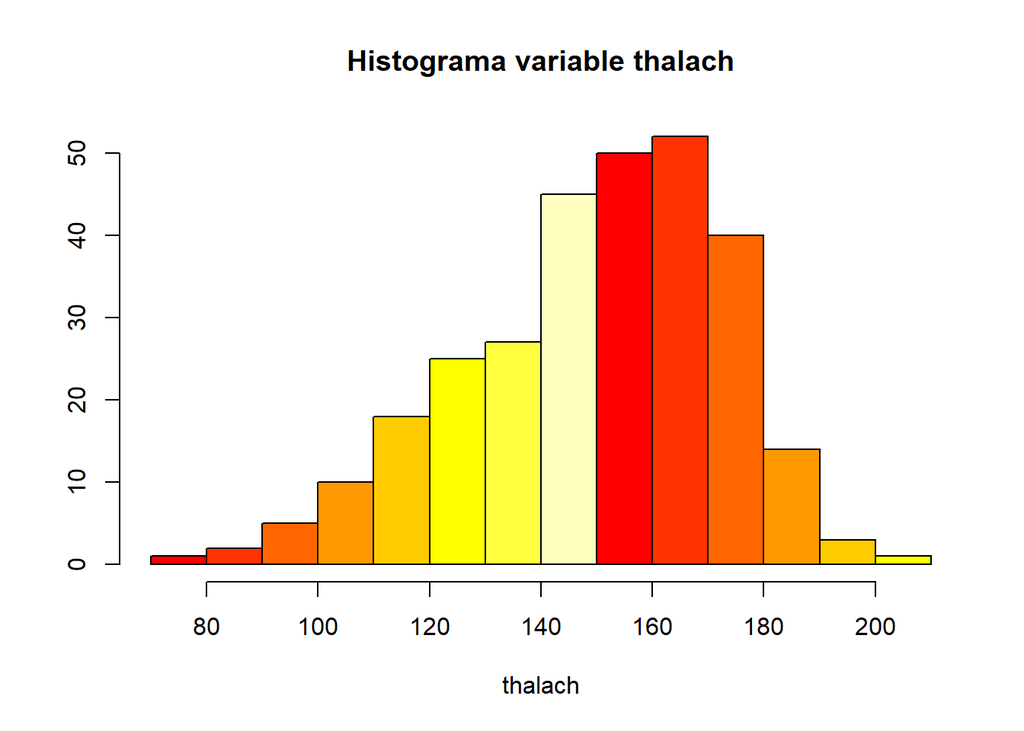

```r
hist(thalach,main = "Histograma variable thalach",ylab=names("thalach"),col=heat.colors(8))
```

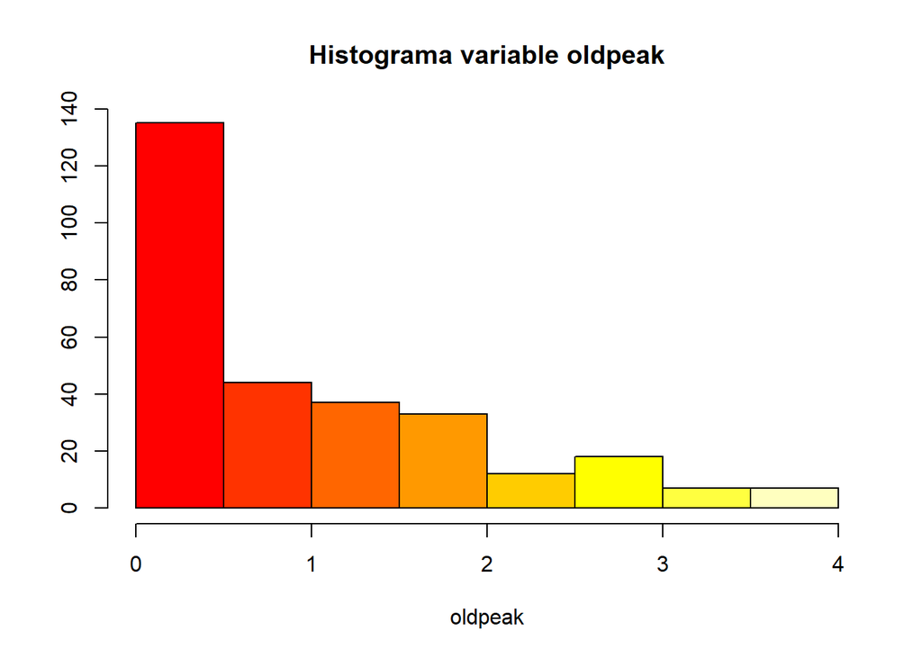

```r
hist(oldpeak,main = "Histograma variable oldpeak",ylab=names("oldpeak"),col=heat.colors(8))
```

```r
#trestbps<-presión arterial en reposo (en mm Hg al ingreso en el hospital)
shapiro.test(trestbps)
```

```
##
##  Shapiro-Wilk normality test
##
## data:  trestbps
## W = 0.965, p-value = 1.571e-06
```

```r
#chol<-suero colestoral en mg/dl
shapiro.test(chol)
```

```
##
##  Shapiro-Wilk normality test
##
## data:  chol
## W = 0.99284, p-value = 0.1734
```

```r
#thalach<-maximo ritmo cardiaco alcanzado
shapiro.test(thalach)
```

```
##
##  Shapiro-Wilk normality test
##
## data:  thalach
## W = 0.97526, p-value = 5.946e-05
```

```r
#oldpeak<-depresión del ST inducida por el ejercicio en relación con el descanso.
shapiro.test(oldpeak)
```

```
##
##  Shapiro-Wilk normality test
##
## data:  oldpeak
## W = 0.85349, p-value = 5.343e-16
```

Respecto a todas la variables, exceptuando la variable chol, los valores del pvalue son muy pequeños y podemos determinar que no tienen una distribución normal (se rechaza la hipótesis nula y por lo tanto asumimos que no hay normalidad en los datos). La variable chol sí podemos considerar que tiene distribución normal (pvalue=0.1734>0.05). Si vemos el gráfico de esa variable podemos ver esa característica.

A continuación trataremos el análisis de la varianza. Vamos a realizar un análisis unifactorial, donde la variable dependiente va a ser chol y la variable independiente será el sexo. En otras palabras, determinaremos si el nivel de chol (suero colestoral en mg/d) viene determinado por el sexo. Al tener muestras grandes de más de 30 no es necesario que confirmemos que la distribución de cada grupo (hombres/mujeres) es normal.

```r
#tapply(diseases$chol, diseases$sex, mean)
#variable chol<-suero colestoral en mg/dl
fligner.test(chol ~ sex, data = diseases)
```

```
##
##  Fligner-Killeen test of homogeneity of variances
##
## data:  chol by sex
## Fligner-Killeen:med chi-squared = 2.9102, df = 1, p-value =
## 0.08802
```

```r
#Otra forma de realizar la prueba varianceTest(diseases$chol[diseases$sex=='0'], diseases$chol[diseases$sex=='1'], method = "fligner")
```

Ahora repetimos la prueba para las variabels trestbps,thalach y oldpeak y siendo la variable dependiente tambien el sexo.

```r
#variable trestbps<-presión arterial en reposo (en mm Hg al ingreso en el hospital)
fligner.test(trestbps ~ sex, data = diseases)
```

```
##
##  Fligner-Killeen test of homogeneity of variances
##
## data:  trestbps by sex
## Fligner-Killeen:med chi-squared = 1.1117, df = 1, p-value = 0.2917
```

```r
#variable thalach<-maximo ritmo cardiaco alcanzado
fligner.test(thalach ~ sex, data = diseases)
```

```
##
##  Fligner-Killeen test of homogeneity of variances
##
## data:  thalach by sex
## Fligner-Killeen:med chi-squared = 3.2289, df = 1, p-value =
## 0.07235
```

```r
#variable oldpeak<-depresión del ST inducida por el ejercicio en relación con el descanso.
fligner.test(oldpeak ~ sex, data = diseases)
```

```
##
##  Fligner-Killeen test of homogeneity of variances
##
## data:  oldpeak by sex
## Fligner-Killeen:med chi-squared = 6.6638, df = 1, p-value =
## 0.009839
```

### 2.1.3 Aplicación de pruebas estadísticas para comparar los grupos de datos. En función de los datos y el objetivo del estudio, aplicar pruebas de contraste de hipótesis, correlaciones, regresiones, etc. Aplicar al menos tres métodos de análisis diferentes.

A continuación se presentarán tres modelos para el análisis de datos, Árbol de Clasificación, Regresión Logística y Naive Bayes.

## Árbol de Clasificación

Vamos a aplicar un árbol de de decisión. Para ello pasamos a factor nuestra variable target. Utilizaremos las 12 primeras variables (las no transformada). Separaremos el dataset en datos de training y datos de testing. Una vez creado el modelo veremos su precisión.

```r
#Pasamos a factor para crear el arbol
diseases$target.tipo = as.factor(diseases$target.tipo)
y <- diseases[,14] #target tipo
X <- diseases[,1:12]
indexes = sample(1:nrow(diseases), size=floor((2/3)*nrow(diseases)))
trainX<-X[indexes,]
trainy<-y[indexes]
testX<-X[-indexes,]
testy<-y[-indexes]
#Primero visualizamos las reglas
modelClasif <- C50::C5.0(trainX, trainy,rules=TRUE )
summary(modelClasif)
```

```
##
## Call:
## C5.0.default(x = trainX, y = trainy, rules = TRUE)
##
##
## C5.0 [Release 2.07 GPL Edition]      Mon Jun 10 20:04:57 2019
## -------------------------------
##
## Class specified by attribute `outcome'
##
## Read 195 cases (13 attributes) from undefined.data
##
## Rules:
##
## Rule 1: (65/7, lift 1.5)
##  cp > 0
##  slope > 1
##  ->  class Con Problemas Cardiacos  [0.881]
##
## Rule 2: (43/5, lift 1.5)
##  cp > 1
##  exang <= 0
##  oldpeak <= 0.9
##  ->  class Con Problemas Cardiacos  [0.867]
##
## Rule 3: (65/8, lift 1.5)
##  slope > 1
##  ca <= 0
##  ->  class Con Problemas Cardiacos  [0.866]
##
## Rule 4: (90/12, lift 1.5)
##  exang <= 0
##  ca <= 0
##  ->  class Con Problemas Cardiacos  [0.859]
##
## Rule 5: (14/2, lift 1.4)
##  cp > 0
##  trestbps <= 115
##  ->  class Con Problemas Cardiacos  [0.813]
##
```

[output cut: 37 more lines]

```
##      15    69    (b): class Sin Problemas Cardiacos
##
##
##  Attribute usage:
##
##   88.21% ca
##   74.87% exang
##   71.28% cp
##   65.64% slope
##   26.67% trestbps
##   22.05% oldpeak
##   18.97% restecg
##
##
## Time: 0.0 secs
```

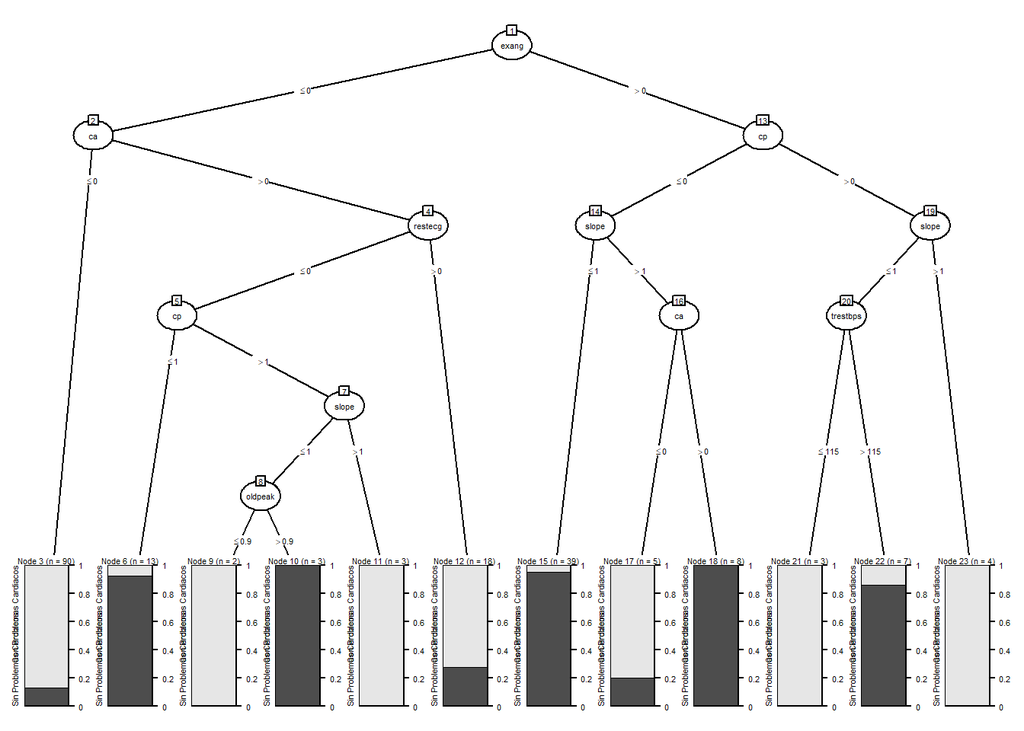

```r
modelClasif <- C50::C5.0(trainX, trainy)
plot(modelClasif,gp = gpar(fontsize = 4))
```

```r
predicted_model <- predict( modelClasif, testX, type="class" )
print(sprintf("La precisión del árbol es: %.4f %%",100*sum(predicted_model == testy) / length(predicted_model)))
```

```
## [1] "La precisión del árbol es: 73.4694 %"
```

```r
testX[,"target"] <- testy
testX[,"PREDICCION"] <-predict( modelClasif, testX, type="class" )

# Mostramos la matriz de confusión con los datos obtenidos en el test
table(testX[,"target"], testX[,"PREDICCION"], dnn=c("Actual","Predicho"))
```

```
##                          Predicho
## Actual                    Con Problemas Cardiacos Sin Problemas Cardiacos
##   Con Problemas Cardiacos                      46                       4
##   Sin Problemas Cardiacos                      22                      26
```

```r
# Exportamos los datos de la predicción
write.csv(testX, file="output/ArbolClasificacion.csv")
```

Vemos la precisión obtenida. Podríamos utilizar el modelo para realizar predicciones para realizar predicciones.

Por otra parte podemos destacar algunas reglas importante que se visualizan como son:

## Modelo de regresión logística

```r
#Preparamos los datos en un data set de entrenamiento y otro de test
set.seed(99)
dataRL <- diseases[,1:13]
train.index <-sample(1:nrow(dataRL), size=floor((2/3)*nrow(dataRL)))
train.data <- dataRL[train.index,]
test.data <- dataRL[-train.index,]


# Creamos el modelo de regresión logistica basado en target, la cual es nuestra variable a predecir
modeloRL <- glm(target~.,data =train.data,family =binomial)
summary(modeloRL)
```

```
##
## Call:
## glm(formula = target ~ ., family = binomial, data = train.data)
##
## Deviance Residuals:
##     Min       1Q   Median       3Q      Max
## -2.4320  -0.3886   0.1733   0.6125   2.1909
##
## Coefficients:
##              Estimate Std. Error z value Pr(>|z|)
## (Intercept)  4.862049   3.112209   1.562 0.118229
## age          0.008092   0.028256   0.286 0.774579
## sex         -2.330506   0.590774  -3.945 7.99e-05 ***
## cp           0.858964   0.241446   3.558 0.000374 ***
## trestbps    -0.026528   0.013759  -1.928 0.053842 .
## chol        -0.018379   0.006375  -2.883 0.003941 **
## fbs         -0.236495   0.701134  -0.337 0.735889
## restecg      0.142187   0.451666   0.315 0.752909
## thalach      0.032014   0.013587   2.356 0.018458 *
## exang       -1.495371   0.526089  -2.842 0.004477 **
## oldpeak     -0.698412   0.292205  -2.390 0.016842 *
## slope        0.298538   0.477539   0.625 0.531867
## ca          -0.656412   0.229686  -2.858 0.004265 **
## ---
## Signif. codes:  0 '***' 0.001 '**' 0.01 '*' 0.05 '.' 0.1 ' ' 1
##
## (Dispersion parameter for binomial family taken to be 1)
##
##     Null deviance: 266.00  on 194  degrees of freedom
## Residual deviance: 135.45  on 182  degrees of freedom
## AIC: 161.45
##
## Number of Fisher Scoring iterations: 6
```

```r
# Agregamos a cada columna del nuestros datos de test la probabilidad y predicción
test.data[, "PROB_SUCCESS"] <- predict(modeloRL, newdata = test.data, type="response")
test.data[, "PREDICCION"] <- ifelse(test.data[, "PROB_SUCCESS"]>=0.5, 1, 0) # si las probabilidades supera el 50% indicamos 1, sino 0 (predicción a la variable target)
head(test.data) # mostramos una muestra de la predicción
```

```
##    age sex cp trestbps chol fbs restecg thalach exang oldpeak slope ca
## 5   57   0  0      120  354   0       1     163     1     0.6     2  0
## 7   56   0  1      140  294   0       0     153     0     1.3     1  0
## 8   44   1  1      120  263   0       1     173     0     0.0     2  0
## 9   52   1  2      172  199   1       1     162     0     0.5     2  0
## 14  64   1  3      110  211   0       0     144     1     1.8     1  0
## 17  58   0  2      120  340   0       1     172     0     0.0     2  0
##    target PROB_SUCCESS PREDICCION
## 5       1    0.4199119          0
## 7       1    0.7934009          1
## 8       1    0.8815506          1
## 9       1    0.8569101          1
## 14      1    0.7283605          1
## 17      1    0.9794220          1
```

```r
# Nos indica la precisión del modelo
print(sprintf("La precisión es: %.4f %%",100*mean(test.data$PREDICCION==test.data$target)))
```

```
## [1] "La precisión es: 80.6122 %"
```

```r
# Mostramos la matriz de confusión con los datos obtenidos en el test
table(test.data[,"target"], test.data[,"PREDICCION"], dnn=c("Actual","Predicho"))
```

```
##       Predicho
## Actual  0  1
##      0 37 12
##      1  7 42
```

```r
# Exportamos los datos de la predicción
write.csv(test.data, file="output/RegresionLogistica.csv")
```

## Algoritmo Naive Bayes

```r
# Instalamos la librería necesaria
if(!require(e1071)){
    install.packages('e1071', repos='http://cran.us.r-project.org')
    library(e1071)
}
# Copiamos el data set para utilizarlo en el algoritmo
dataNV <- diseases[,c("age.tipo","cp.tipo","trestbps.tipo","chol.tipo","restecg.tipo","exang.tipo","oldpeak.tipo","slope.tipo","ca.tipo","target")]
dataNV$target <- as.factor(dataNV$target)

# Creamos nuestros datos para el modelo y test
trainNV.index <-sample(1:nrow(dataNV), size=floor((2/3)*nrow(dataNV)))
trainNV.data <- dataNV[trainNV.index,]
testNV.data <- dataNV[-trainNV.index,]

# Ejecutamos el algoritmo
mod <- naiveBayes(target~ ., data = trainNV.data)
summary(mod)
```

```
##           Length Class  Mode
## apriori   2      table  numeric
## tables    9      -none- list
## levels    2      -none- character
## isnumeric 9      -none- logical
## call      4      -none- call
```

```r
# Guardamos los valores predichos en el data set de test para luego compararlos
testNV.data[, "PREDICCION"] <- predict(mod, testNV.data)

# Vemos una muestra de las predicciones
head(testNV.data)
```

```
##                   age.tipo cp.tipo             trestbps.tipo
## 2             Menores a 40       2 Mayor a 100 y menor a 150
## 3  Mayor a 40 y menor a 50       1 Mayor a 100 y menor a 150
## 6  Mayor a 50 y menor a 60       0 Mayor a 140 y menor a 180
## 10 Mayor a 50 y menor a 60       2 Mayor a 140 y menor a 180
## 11 Mayor a 50 y menor a 60       0 Mayor a 140 y menor a 180
## 16 Mayor a 50 y menor a 60       2 Mayor a 100 y menor a 150
##                    chol.tipo restecg.tipo exang.tipo          oldpeak.tipo
## 2  Mayor a 200 y menor a 300            1          0 Mayor a 3 y menor a 4
## 3  Mayor a 200 y menor a 300            0          0 Mayor a 1 y menor a 2
## 6                Menor a 200            1          0             Menor a 1
## 10               Menor a 200            1          0 Mayor a 1 y menor a 2
## 11 Mayor a 200 y menor a 300            1          0 Mayor a 1 y menor a 2
## 16 Mayor a 200 y menor a 300            1          0 Mayor a 1 y menor a 2
##    slope.tipo ca.tipo target PREDICCION
## 2           0       0      1          0
## 3           2       0      1          1
## 6           1       0      1          1
## 10          2       0      1          1
## 11          2       0      1          1
## 16          1       0      1          1
```

```r
# Nos indica la precisión del modelo
print(sprintf("La precisión es: %.4f %%",100*mean(testNV.data$PREDICCION==testNV.data$target)))
```

```
## [1] "La precisión es: 79.5918 %"
```

```r
# Vemos una tabla de confusión y comparamos los datos predecidos con los reales
table(testNV.data$target, testNV.data$PREDICCION, dnn = c("Actual", "Predicha"))
```

```
##       Predicha
## Actual  0  1
##      0 35 10
##      1 10 43
```

```r
# Exportamos los datos de la predicción
write.csv(testNV.data, file="output/NaiveBayes.csv")
```

## Cross Validation para los modelos propuestos

Pasaremos a revisar con K iteraciones la validez de las predicciones de los modelos seleccionados. La cantidad de iteraciones elegidas es 10.

```r
library(caret)
folds <- createFolds(dataRL$target, k = 10)

# Cross Validation para Árbol de Clasificación
# Iteramos el método de Árbol de Clasificación en K veces para probar nuestro modelo y predecir su verdadera efectividad
cvC50ArbolClasificacion <- lapply(folds, function(x){
  trainX<-X[-x,]
  trainy<-y[-x]
  testX<-X[x,]
  testy<-y[x]
  modelClasif <- C50::C5.0(trainX, trainy)
  predicted_model <- predict( modelClasif, testX, type="class" )
  precision <- sum(predicted_model == testy) / length(predicted_model)
  return(precision)
})
#Calculamos la media aritmética de k iteraciones
precisionC50ArbolClasificacion <- mean(as.numeric(cvC50ArbolClasificacion))
print(sprintf("La precisión para Árbol de clasificación en Cross Validation: %.4f %%",100*precisionC50ArbolClasificacion))
```

```
## [1] "La precisión para Árbol de clasificación en Cross Validation: 75.5057 %"
```

```r
# Cross Validation para Regresion Logistica
# Iteramos el método Regresion Logistica en K veces para probar nuestro modelo y predecir su verdadera efectividad
cvRegresionLogistica <- lapply(folds, function(x){
  training_fold <- dataRL[-x, ]
  test_fold <- dataRL[x, ]
  clasificador <- glm(target ~ ., family = binomial, data = training_fold)
  y_pred <- predict(clasificador, type = 'response', newdata = test_fold)
  y_pred <- ifelse(y_pred > 0.5, 1, 0)
  #y_pred <- factor(y_pred, levels = c("0", "1"), labels = c("NoPulsar", "Pulsar"))
  cm <- table(test_fold$target, y_pred)
  precision <- (cm[1,1] + cm[2,2]) / (cm[1,1] + cm[2,2] +cm[1,2] + cm[2,1])
  return(precision)
})
#Calculamos la media aritmética de k iteraciones
precisionRegresionLogistica <- mean(as.numeric(cvRegresionLogistica))
print(sprintf("La precisión de Regresión Logística en Cross Validation: %.4f %%",100*precisionRegresionLogistica))
```

```
## [1] "La precisión de Regresión Logística en Cross Validation: 81.2414 %"
```

```r
# Cross Validation para NaiveBayes
# Iteramos el método de NaiveBayes en K veces para probar nuestro modelo y predecir su verdadera efectividad
cvNaiveBayes <- lapply(folds, function(x){
  training_fold <- dataNV[-x, ]
  test_fold <- dataNV[x, ]
  clasificador <- naiveBayes(target ~ ., data = training_fold)
  y_pred <- predict(clasificador, newdata = test_fold)
  cm <- table(test_fold$target, y_pred)
  precision <- (cm[1,1] + cm[2,2]) / (cm[1,1] + cm[2,2] +cm[1,2] + cm[2,1])
  return(precision)
})

#Calculamos la media aritmética de k iteraciones
precisionNaiveBayes <- mean(as.numeric(cvNaiveBayes))
print(sprintf("La precisión para NaiveBayes en Cross Validation: %.4f %%",100*precisionNaiveBayes))
```

```
## [1] "La precisión para NaiveBayes en Cross Validation: 79.8736 %"
```

A continuación se mostrarán los métodos ordenados descendentemente por el porcentaje y error de predicción, la varianza y desviación estandar de todos los modelos que se sometieron al cross validation.

```r
vectorMedia = c(precisionC50ArbolClasificacion*100,precisionRegresionLogistica*100,precisionNaiveBayes*100)
vectorError = c(100-precisionC50ArbolClasificacion*100,100-precisionRegresionLogistica*100,100-precisionNaiveBayes*100)
vectorVarianza = c(var(as.numeric(cvC50ArbolClasificacion)*100), var(as.numeric(cvRegresionLogistica)*100), var(as.numeric(cvNaiveBayes)*100))
vectorDesviacion = c(sd(as.numeric(cvC50ArbolClasificacion)*100), sd(as.numeric(cvRegresionLogistica)*100), sd(as.numeric(cvNaiveBayes)*100))
M1 = cbind(c("Árbol Clasificacion", "Regresion Logistica","Naive Bayes"),vectorMedia,vectorError, vectorVarianza,vectorDesviacion)
colnames(M1) <- c("Modelo", "Porcentaje Predicción", "Error", "Varianza", "Desviación")
```

```r
# Ordenamos y mostramos los resultados
M1[order(M1[,"Porcentaje Predicción"],decreasing = TRUE), ]
```

```
##      Modelo                Porcentaje Predicción Error
## [1,] "Regresion Logistica" "81.2413793103448"    "18.7586206896552"
## [2,] "Naive Bayes"         "79.8735632183908"    "20.1264367816092"
## [3,] "Árbol Clasificacion" "75.5057471264368"    "24.4942528735632"
##      Varianza           Desviación
## [1,] "25.7095462485871" "5.07045818921595"
## [2,] "39.8187049514834" "6.31020641116306"
## [3,] "75.3143670821039" "8.67838505034802"
```

Los resultados del Cross Validation nos puede dar la visión por cuál de los modelos nos podemos inclinar, entregando un mejor resultado en la verisidad de la predicción. Para selección del modelo apropiado, podemos tomar como referencia el porcentaje de predicción +- la desviación estandar.

## Probando la eliminación slope por correlación entre oldspeak

Ahora veremos eliminado la variable slope, probando si la correlación entre oldspeak es suficiente como para eliminarla por redundancia.

```r
X$slope <- NULL

# Cross Validation para Árbol de Clasificación sin variable slope
cvC50ArbolClasificacion <- lapply(folds, function(x){
  trainX<-X[-x,]
  trainy<-y[-x]
  testX<-X[x,]
  testy<-y[x]
  modelClasif <- C50::C5.0(trainX, trainy)
  predicted_model <- predict( modelClasif, testX, type="class" )
  precision <- sum(predicted_model == testy) / length(predicted_model)
  return(precision)
})
#Calculamos la media aritmética de k iteraciones
precisionC50ArbolClasificacion <- mean(as.numeric(cvC50ArbolClasificacion))
print(sprintf("La precisión para Árbol de clasificación en Cross Validation: %.4f %%",100*precisionC50ArbolClasificacion))
```

```
## [1] "La precisión para Árbol de clasificación en Cross Validation: 76.8966 %"
```

```r
dataRL <- diseases[,1:13]
dataRL$slope <- NULL
# Cross Validation para Regresion Logistica  sin variable slope
cvRegresionLogistica <- lapply(folds, function(x){
  training_fold <- dataRL[-x, ]
  test_fold <- dataRL[x, ]
  clasificador <- glm(target ~ ., family = binomial, data = training_fold)
  y_pred <- predict(clasificador, type = 'response', newdata = test_fold)
  y_pred <- ifelse(y_pred > 0.5, 1, 0)
  #y_pred <- factor(y_pred, levels = c("0", "1"), labels = c("NoPulsar", "Pulsar"))
  cm <- table(test_fold$target, y_pred)
  precision <- (cm[1,1] + cm[2,2]) / (cm[1,1] + cm[2,2] +cm[1,2] + cm[2,1])
  return(precision)
})
#Calculamos la media aritmética de k iteraciones
precisionRegresionLogistica <- mean(as.numeric(cvRegresionLogistica))
print(sprintf("La precisión de Regresión Logística en Cross Validation: %.4f %%",100*precisionRegresionLogistica))
```

```
## [1] "La precisión de Regresión Logística en Cross Validation: 82.2759 %"
```

```r
dataNV <- diseases[,c("age.tipo","cp.tipo","trestbps.tipo","chol.tipo","restecg.tipo","exang.tipo","oldpeak.tipo","slope.tipo","ca.tipo","target")]
dataNV$target <- as.factor(dataNV$target)
dataNV$slope.tipo<- NULL
# Cross Validation para NaiveBayes  sin variable slope
cvNaiveBayes <- lapply(folds, function(x){
  training_fold <- dataNV[-x, ]
  test_fold <- dataNV[x, ]
  clasificador <- naiveBayes(target ~ ., data = training_fold)
  y_pred <- predict(clasificador, newdata = test_fold)
  cm <- table(test_fold$target, y_pred)
  precision <- (cm[1,1] + cm[2,2]) / (cm[1,1] + cm[2,2] +cm[1,2] + cm[2,1])
  return(precision)
})

#Calculamos la media aritmética de k iteraciones
precisionNaiveBayes <- mean(as.numeric(cvNaiveBayes))
print(sprintf("La precisión para NaiveBayes en Cross Validation: %.4f %%",100*precisionNaiveBayes))
```

```
## [1] "La precisión para NaiveBayes en Cross Validation: 79.8851 %"
```

```r
vectorMedia = c(precisionC50ArbolClasificacion*100,precisionRegresionLogistica*100,precisionNaiveBayes*100)
vectorError = c(100-precisionC50ArbolClasificacion*100,100-precisionRegresionLogistica*100,100-precisionNaiveBayes*100)
vectorVarianza = c(var(as.numeric(cvC50ArbolClasificacion)*100), var(as.numeric(cvRegresionLogistica)*100), var(as.numeric(cvNaiveBayes)*100))
vectorDesviacion = c(sd(as.numeric(cvC50ArbolClasificacion)*100), sd(as.numeric(cvRegresionLogistica)*100), sd(as.numeric(cvNaiveBayes)*100))
M1 = cbind(c("Árbol Clasificacion", "Regresion Logistica","Naive Bayes"),vectorMedia,vectorError, vectorVarianza,vectorDesviacion)
colnames(M1) <- c("Modelo", "Porcentaje Predicción", "Error", "Varianza", "Desviación")
# Ordenamos y mostramos los resultados
M1[order(M1[,"Porcentaje Predicción"],decreasing = TRUE), ]
```

```
##      Modelo                Porcentaje Predicción Error
## [1,] "Regresion Logistica" "82.2758620689655"    "17.7241379310345"
## [2,] "Naive Bayes"         "79.8850574712644"    "20.1149425287356"
## [3,] "Árbol Clasificacion" "76.8965517241379"    "23.1034482758621"
##      Varianza           Desviación
## [1,] "37.4298674417581" "6.1179953777163"
## [2,] "41.1561779774225" "6.41530809684325"
## [3,] "83.1138709061817" "9.11668091501407"
```

Como podemos observar, ha aumentado levemente la precisión en la predicción al eliminar la variable slope, aunque la desviación estandar también aumento levemente, por lo que no podemos considerar relevante la eliminación de la variable en nuestros modelos predicctivos.

## 2.2 Representación de los resultados a partir de tablas y gráficas.

## 2.3 Resolución del problema. A partir de los resultados obtenidos, ¿cuáles son las conclusiones? ¿Los resultados permiten responder al problema?

Lo que se quería con este estudio era por una parte detectar características de los pacientes que infuyen en que se parezca la enfermedad cardíaca o no. Por otra parte poder predecir de una manera precisa si los individuos con unas características concretas sufren la enfermedad en un porcentaje alto.

El primer punto lo hemos conseguido responder con el análisis de los datos visuales y con la ayuda de algun análisis como la creación del árbol de clasificación que nos ha dado tambien una reglas. Por ejemplo, vemos que por diferenciando por sexo las mujeres tienen un más problemas cardíacos en porcentaje y que a menos oldpeak la probabilidad de sufrir la enfermedad es mayor. Las reglas obtenidas mediante el modelo C5.0 nos ha dado la información, como la siguiente:

El segundo objetivo, el de obtener un modelo de predicción también ha sido conseguido. Se ha obtenido un modelo de regresión logística con más del 80% de precisión para predecir si una persona parece la enfermedad o no.

Evidentemente, si se necesitara profundizar en algun aspecto se tendría que hacer una revisión para ajustar los modelos o buscar otros que se adecuen a las necesidades.

Para resolver las problemáticas hemos tenido que realizar las tareas habituales en un proyecto de datamining como son la limpieza y transformación de datos, la visualización y la generación de modelos.

## 2.4 Código: Hay que adjuntar el código, preferiblemente en R, con el que se ha realizado la limpieza, análisis y representación de los datos. Si lo preferís, también podéis trabajar en Python.

El código lo pueden encontrar en https://github.com/fmorenono/practica2

## 2.5 Referencias

Referenciamos a continuación fuetes de información utilizado durante la realización de la práctica.

-El Data Set seleccionado está disponible en: https://www.kaggle.com/ronitf/heart-disease-uci

-Estudio ANOVA: https://rpubs.com/Joaquin_AR/219148

-Test de Kruskal-Wallis: https://rpubs.com/Joaquin_AR/219504